# FAPESP - Alavancando a Ciência Brasileira

# Quem é a FAPESP?

A FAPESP - Fundação de Amparo à Pesquisa do Estado de São Paulo - é uma das principais agências de fomento à pesquisa científica e tecnológica do país. Com autonomia garantida por lei, a FAPESP está ligada à Secretaria de Desenvolvimento Econômico.

Com um orçamento anual correspondente a 1% do total da receita tributária do Estado, a FAPESP apoia a pesquisa e financia a investigação, o intercâmbio e a divulgação da ciência e da tecnologia produzida em São Paulo.

Para ilustrar a receita e a quantidade de despachos realizados pela FAPESP, foi realizada a raspagem dos dados de 2 tabelas disponíveis no site da FAPESP.

# Vamos trabalhar - Pacotes necessários

```r
# Carregando pacotes --------------------------------------------------------------------------
library(tidyverse)
library(httr)
library(xml2)
library(rvest)
library(viridis)
library(janitor)
library(knitr)

#  Tirar conotação cientifica ------------------------------------------------------------------

options(scipen = 999)
```

# Primeiro passo - Raspando as informações sobre as receitas da FAPESP

No próprio site da [FAPESP](https://fapesp.br/9250/evolucao-das-receitas) há uma seção com as estatisticas da instituição. Na seção que detalha as receitas da FAPESP há uma tabela contendo todas as receitas. A tabela abaixo (Figura 1) foi a primeira motivação para a raspagem dos dados.

[figure not shown]

Para extrair os dados da tabela foi realizada a inspeção do HTML para verificar a forma de requisição. Na aba “rede” nota-se que o primeiro item **evolução-das-receitas** apresenta bastante requisições e tem um conteudo do tipo HTML. Ainda, ao inspecionar a aba “visualizar” notei que a tabela esta presente neste objeto, me dando indícios que a requisição deste item me permitiria chegar a tabela alvo. A requisição deste item é do tipo *GET* e o *Status* deve ser 200.

[figure not shown]

```r
# GET URL -------------------------------------------------------------------------------------

url_fapesp <- "https://fapesp.br/9250/evolucao-das-receitas"

get_url_fapesp <- GET(url_fapesp)

# verificando status da requisição

get_url_fapesp
```

[output not shown]

Conforme podemos observar, a requisição foi realizada com sucesso. Em seguida, ainda nas ferramentas de desenvolvedor, mas agora na aba **elementos**, ao clicar na tabela, identifiquei a tag **table** (Figure 3) e, investi uma tentativa nela para ver se conseguia extrair a tabela.

[figure not shown]

Após ler o HTML, busquei a tag **table** e, utilizando a função *html_table* do pacote *rvest* verifiquei que obtive sucesso em acessar a tabela de receitas da FAPESP. Contudo, ainda era necessário organizar a tabela visto que as colunas númerivas vieram como strings.

```r
# Scraping o html --------------------------------------------------------------------------------

tb_fapesp <-
  get_url_fapesp |>
  read_html() |>
  xml_find_all(xpath = "//table") |>
  html_table(header = TRUE)

head(tb_fapesp)
```

```
## [[1]]
## # A tibble: 61 x 7
##    Exercícios Receitas `Transferências do ~ `Outras receita~ `Total da receita ~
##         <int> <chr>    <chr>                <chr>            <chr>
##  1       2022 R$       499.489.652          50.125.824       549.615.476
##  2       2021 R$       1.693.258.505        91.327.446       1.784.585.951
##  3       2020 R$       1.405.370.233        35.924.513       1.441.294.746
##  4       2019 R$       1.350.534.401        102.661.381      1.453.195.782
##  5       2018 R$       1.179.770.909        190.507.777      1.370.278.686
##  6       2017 R$       1.111.410.356        227.584.193      1.338.994.548
##  7       2016 R$       1.057.714.553        245.520.259      1.303.234.812
##  8       2015 R$       1.045.335.371        105.405.812      1.150.741.183
##  9       2014 R$       998.745.173          181.061.609      1.179.806.782
## 10       2013 R$       957.047.596          83.040.285       1.040.087.881
## # ... with 51 more rows, and 2 more variables: ...
```

Para limpeza da tabela foi utilizada funções para ajustar o nome das variáveis (utilizando o pacotes Janitor), extrair pontos entre os números (pacote Stringr) e conversáo do tipo da variável. Após os ajustes,nota-se que as colunas agora apresentam tipo e nome adequado para análise.

```r
# Arrumando a base de dados

fapesp_arrumada <- tb_fapesp[[1]] |>
  clean_names() |> # arrumando os nomes
  mutate( # tirando o ponto dos vetores de caracteres para converter em numeric
    transferencias_do_tesouro = as.numeric(str_remove_all(transferencias_do_tesouro,
                                                          pattern = "[.]")),
    outras_receitas = as.numeric(str_remove_all(outras_receitas,
                                                pattern = "[.]")),
    total_da_receita_do_ano = as.numeric(str_remove_all(total_da_receita_do_ano,
                                                        pattern = "[.]")),
    reversao_de_diferimento_de_receitas_saldos_de_exercicios_anteriores = as.numeric(str_remove_all(reversao_de_diferimento_de_receitas_saldos_de_exercicios_anteriores,
                                                                                                    pattern = "[.]")),
    total = as.numeric(str_remove_all(total,
                                      pattern = "[.]"))/1000000
  )
glimpse(fapesp_arrumada)
```

```
## Rows: 61
## Columns: 7
## $ exercicios                                                          <int> 20~
## $ receitas                                                            <chr> "R~
## $ transferencias_do_tesouro                                           <dbl> 49~
## $ outras_receitas                                                     <dbl> 50~
## $ total_da_receita_do_ano                                             <dbl> 54~
## $ reversao_de_diferimento_de_receitas_saldos_de_exercicios_anteriores <dbl> NA~
## $ total                                                               <dbl> NA~
```

Segue abaixo documentação tabela obtida:

**exercicios** = ano da receita;

**receitas** = moeda no qual a receita foi recebida;

**transferencias_do_tesouro** = recurso com origem do tesouro;

**outras_receitas** = valor obtido por meio de outros recursos;

**total_da_receita_do_ano** = total da receita no ano;

**reversao_de_diferimento_de_receitas_saldos_de_exercicios_anteriores** = recurso recebido por meio de reversão de diferimento de receitas/saldo de anos anteriores;

**total** = total da receita no ano;

Por fim, foi criado um .csv da base de dados organizada para utilização futura.

```r
# Criando um .csv  ----------------------------------------------------------------------------

fapesp_arrumada |>
  filter(exercicios >= 1994 & exercicios < 2022) |>
  write_csv(file = "adjusted_data/fapesp_receitas_1994_2021.csv")
```

# Segundo passo - Raspando as informações sobre os despachos da FAPESP

Ainda no site da FAPESP, mas agora na página onde se encontra as informações sobre [Prazos médios para análise e quantidade de propostas despachadas (2010 a 2019)](https://fapesp.br/estatisticas/analise) também há uma tabela (Figura 4). Esta tabela, em particular a parte que detalha todos os despachos, foi a segunda motivação para a raspagem dos dados.

[figure not shown]

Em seguida, foi realizada a inspeção do HTML para verificar a forma de requisição. Na aba “rede” verifiquei que o primeiro item **https://fapesp.br/estatisticas/analise** também apresentava um elevado número de requisições e tinha conteúdo do tipo HTML, dando indício que a requisição deste item me daria a tabela alvo. A requisição deste item é do tipo *GET* e o *Status* deve ser 200.

[figure not shown]

```r
# GET URL -------------------------------------------------------------------------------------

url_fapesp_despacho <- "https://fapesp.br/estatisticas/analise"

get_url_fapesp_despacho <- GET(url_fapesp_despacho)

# verificando status da requisição

get_url_fapesp_despacho
```

[output not shown]

[figure not shown]

Após checar a tag **table** utilizando a função *html_table* do pacote *rvest*, novamente, obtive sucesso em acessar a tabela que, assim como a outra tabela, também precisa de uma faxina.

```r
# Scraping o html ------------------------------------------------------------------------------

get_url_fapesp_despacho <-
  get_url_fapesp_despacho |>
  read_html() |>
  xml_find_all(xpath = "//table") |>
  html_table(header = TRUE) |>
  pluck(1)

head(get_url_fapesp_despacho)
```

```
## # A tibble: 6 x 12
##   ``     ``     `2010`  `2011`  `2012` `2013` `2014` `2015` `2016` `2017` `2018`
##   <chr>  <chr>  <chr>   <chr>   <chr>  <chr>  <chr>  <chr>  <chr>  <chr>  <chr>
## 1 TODOS~ Quant~ 17.946  18.553  19.551 20.020 20.135 19.171 19.753 19.428 19.594
## 2 TODOS~ Prazo~ 78      69      65     70     66     64     65     72     69
## 3 TODOS~ TODOS~ TODOS ~ TODOS ~ TODOS~ TODOS~ TODOS~ TODOS~ TODOS~ TODOS~ TODOS~
## 4 AUXÍL~ AUXÍL~ AUXÍLI~ AUXÍLI~ AUXÍL~ AUXÍL~ AUXÍL~ AUXÍL~ AUXÍL~ AUXÍL~ AUXÍL~
## 5 Auxíl~ Quant~ 459     497     552    621    642    653    587    643    544
## 6 Auxíl~ Prazo~ 48      42      43     48     50     55     57     62     58
## # ... with 1 more variable: 2019 <chr>
```

Para limpeza da tabela foi utilizada funções para ajustar o nome das variáveis (utilizando o pacote Janitor), extrair pontos entre os números (utilizando o pacote Stringr), conversáo do tipo da variável e, por fim, uma pivotagem (utilizando o pacote Tidyr). Após os ajustes pode-se observar que as colunas agora apresentam tipo e nome adequado para análise do total de despachos por ano.

```r
# Arrumando a base - TOTAL DE DESPACHOS

total_despachos <-
   get_url_fapesp_despacho[1:2,2:12] |>
   clean_names() |>
   mutate(
     x2010 = as.numeric(x2010),
     x2011 = as.numeric(x2011),
     x2012 = as.numeric(x2012),
     x2013 = as.numeric(x2013),
     x2014 = as.numeric(x2014),
     x2015 = as.numeric(x2015),
     x2016 = as.numeric(x2016),
     x2017 = as.numeric(x2017),
     x2018 = as.numeric(x2018),
     x2019 = as.numeric(x2019)
   ) |>
     pivot_longer(cols = !x,names_to = "Ano",values_to = "Quantidade") |>
     mutate(
       Ano = as.factor(str_remove_all(string = Ano, pattern = "[x]")),
       Quantidade = as.numeric(Quantidade*1000)
       ) |>
  rename(
   despachos = x
  )

glimpse(total_despachos)
```

```
## Rows: 20
## Columns: 3
## $ despachos  <chr> "Quantidade", "Quantidade", "Quantidade", "Quantidade", "Qu~
## $ Ano        <fct> 2010, 2011, 2012, 2013, 2014, 2015, 2016, 2017, 2018, 2019,~
## $ Quantidade <dbl> 17946, 18553, 19551, 20020, 20135, 19171, 19753, 19428, 195~
```

Segue abaixo documentação tabela obtida:

**despachos** = quantidade ou prazo de despachos por ano;

**Ano** = Ano referência;

**Quantidade** = quantidade total ;

Por fim, foi criado um .csv da base de dados organizada para análise.

```r
# Criando um .csv -----------------------------------------------------------------------------

total_despachos |>
  write_csv(file = "adjusted_data/fapesp_despachos_2010-2019.csv")
```

# Verificando a receita da FAPESP

Como podemos verificar no gráfico abaixo, a FAPESP apresenta uma progressiva receita desde 1994, indicando um progressivo investimento na ciência.

[figure not shown]

# Quantidade e prazo médio (em dias) para despacho de resultados da FAPESP

Com o aumento das receitas anuais é de se esperar que a FAPESP apresente também uma elevada demanda de trabalho para avaliar e responder a pesquisadores do estado de São Paulo fazendo pedidos de financiamento. Realmente, podemos observar uma quantidade elevada de despachos pela FAPESP. Esses despachos acontecem em aproximadamente 70-60 dias após a submissão.

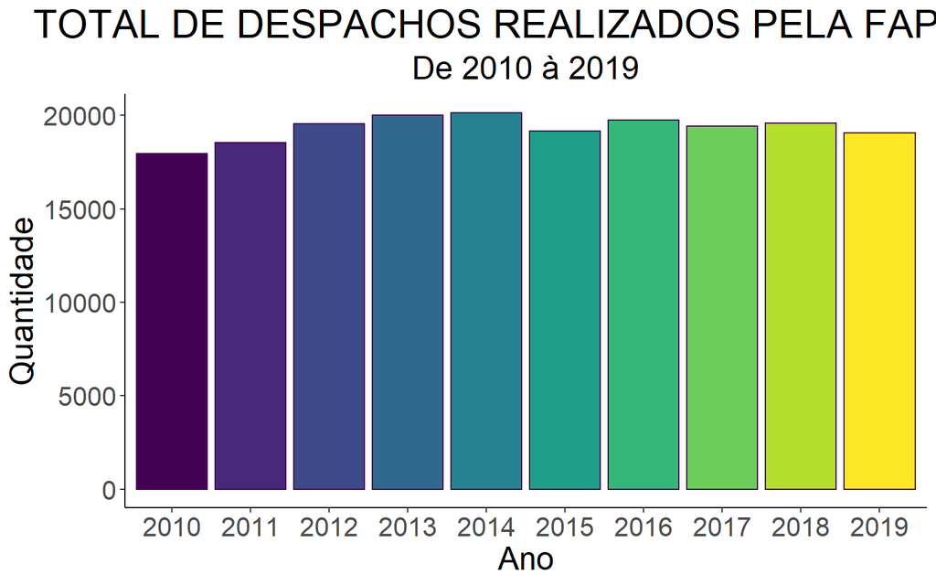

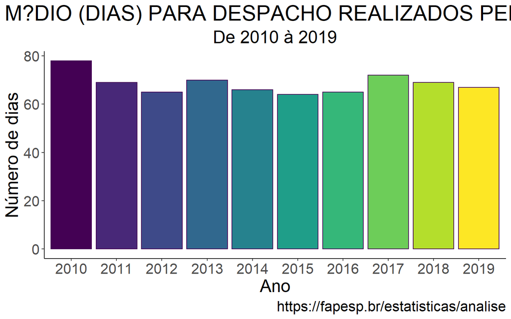

# CONSIDERAÇÕES FINAIS